# Aventure 2 - Github et la visualisation de données numériques

## Boite à moustache

💡 **Explication** : Une boîte à moustaches permet de visualiser la dispersion d’une variable numérique et d’identifier d’éventuelles valeurs aberrantes. Ici, nous allons examiner la distribution de la longueur des nageoires (`flipper_length_mm`).

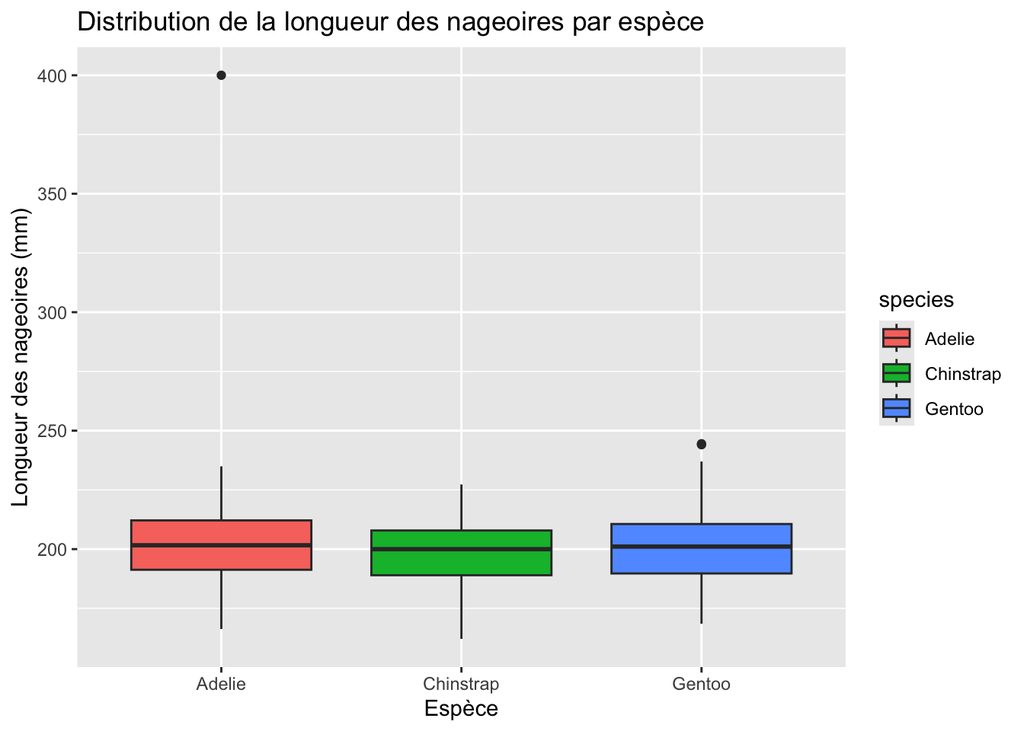

```r
ggplot(penguins_mission, aes(x = species, y = flipper_length_mm, fill = species)) +
  geom_boxplot() +
  labs(title = "Distribution de la longueur des nageoires par espèce",
       x = "Espèce",
       y = "Longueur des nageoires (mm)")
```

**Exemple**

Ajoutez une variable pour différencier les îles et observez si certaines îles présentent des valeurs plus extrêmes.

**Exercice**

Trouvez le numéro de ligne de l’observation qui semble être une valeur aberrante dans la longueur des nageoires.

**🧑‍💼 Jules – Observation anormale**

Quel est le **numéro de ligne** de l’observation qui a une **nageoire de 400 mm** (valeur aberrante ajoutée exprès) ?  
1. 1  
2. 11  
3. 42  
4. 113

**✅ Réponse de Jules**

L’observation aberrante est **ligne 11**.  
Elle a été ajoutée exprès pour tester ta capacité à détecter visuellement les anomalies.

**Pensez à générer votre rapport, committer vos modifications et pousser sur GitHub pour garder une trace de votre travail ! 🚀**

**Exercice (optionnel)**

Dans le graphique précédent, le titre de la légende est “species”, en anglais, qui est par default le nom de la variable. Changez-le pour “Espèce” en français. Vous devez trouver par vous-même comment faire cela.

## Nuages de point (scatter plot)

💡 **Explication** : Un scatter plot (ou nuage de points) permet de visualiser la relation entre deux variables numériques. Ici, nous allons examiner la relation entre la longueur du bec (`bill_length_mm`) et la profondeur du bec (`bill_depth_mm`).

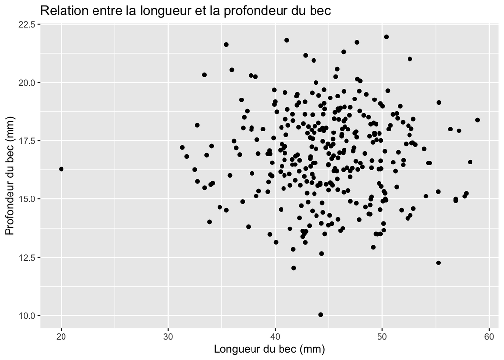

```r
ggplot(penguins_mission, aes(x = bill_length_mm, y = bill_depth_mm)) +
  geom_point() +
  labs(title = "Relation entre la longueur et la profondeur du bec",
       x = "Longueur du bec (mm)",
       y = "Profondeur du bec (mm)")
```

**Exemple**

Ajoutez une variable de couleur pour différencier les îles et observez si certaines îles présentent des relations différentes.

Pour connaître la prochaine demande de la chercheuse, voici le message que vous venez de recevoir :

```
[1] "Je veux voir la relation entre la longueur du bec et la masse corporelle sous forme d'un nuage de points. Peux-tu vérifier s'il y a des valeurs aberrantes pour ces deux variables ?"
```

**Exercice**

Modifiez le scatter plot pour afficher la relation souhaitée par la chercheuse. Est-ce que vous trouver qu’un point à l’air bizarre? Si oui, quel est son numéro de ligne?

**Pensez à générer votre rapport, committer vos modifications et pousser sur GitHub pour garder une trace de votre travail ! 🚀**

# 🧮 Statistiques descriptives

💡 **Explication** : Les statistiques descriptives permettent de résumer et comprendre rapidement un ensemble de données. Elles se divisent en plusieurs catégories :

- **📌 Tendance centrale** : moyenne, médiane
- **📌 Dispersion** : variance, écart-type, coefficient de variation
- **📌 Distribution** : min, max, quartiles
- **📌 Asymétrie et aplatissement** : skewness et kurtosis (optionnel)

Nous allons voir comment obtenir ces statistiques en R avec `dplyr`. En utilisant la fonction `summarise` il est très facile de calculer des statistiques descriptives sur une variable:

```r
penguins_mission %>%
  summarise(
    mean_bill_length = mean(bill_length_mm, na.rm = TRUE), #  moyenne
    median_bill_length = median(bill_length_mm, na.rm = TRUE), # mediane
    sd_bill_length = sd(bill_length_mm, na.rm = TRUE), # écart-type
    var_bill_length = var(bill_length_mm, na.rm = TRUE), # variance
    min_bill_length = min(bill_length_mm, na.rm = TRUE), # min
    max_bill_length = max(bill_length_mm, na.rm = TRUE), # max
    q1_bill_length = quantile(bill_length_mm, 0.25, na.rm = TRUE), # Q1
    q3_bill_length = quantile(bill_length_mm, 0.75, na.rm = TRUE) #Q3
  )
```

**📜 Instructions laissées par la chercheuse**

Pour connaître la première demande de la chercheuse, elle viens de vous a envoyé ceci :

```
[1] "Quelle espèce de pingouin a le bec le plus long en moyenne ? Le plus variable?"
```

**Exercice**

Répondez de facon précise dans votre journal de bord à la demande du Docteur Adélie.

✅ Méthode rapide avec `across()` ans `dplyr`

Tu peux appliquer toutes les fonctions statistiques sur plusieurs colonnes d’un coup :

```r
penguins_mission %>%
  group_by(species) %>%
  summarise(across(bill_length_mm, list(
    mean = mean, median = median, sd = sd, var = var,
    min = min, max = max, q1 = ~quantile(.x, 0.25), q3 = ~quantile(.x, 0.75)
  )))
```

💡 Avantages :

- Moins de répétition de code
- Facilement extensible à plusieurs variables en changeant `bill_length_mm` par `c(bill_length_mm, flipper_length_mm)`

**🧑‍💼 Jules – Valeur moyenne du ratio**

Tu as calculé `bill_ratio` plus haut avec la fonction `mutate`. Si la moyenne est 2.94 et que ton collègue s’attend à 3.5, que peux-tu conclure ?  
1. Le collègue a raison, 2.94 ≈ 3.5  
2. Il faut plus d’échantillons  
3. Tes résultats contredisent son hypothèse  
4. Le ratio n’est pas utile

**✅ Réponse de Jules**

Une moyenne de **2.94**, bien inférieure à 3.5, contredit l’hypothèse du collègue.  
Cela suggère une différence, mais tu pourrais aussi comparer les distributions, par exemple avec un histogramme ou un boxplot, pour mieux visualiser les variations.

## Visualisation avancée et statistiques descriptives (optionnel)

Nous allons maintenant créer un boxplot détaillé qui affiche :

- Les quartiles (Q1-Q3)
- La médiane
- La moyenne
- Les valeurs extrêmes

**Exercice**

Parmis les stastiques précédentes, laquelle n’est habituellement pas affichée dans une boite à moustache? 🤔

Avant de partir en antartique, la chercheuse vous as laissé un bout de code (vraisemblablement un début de travail qu’elle souhaitait faire);

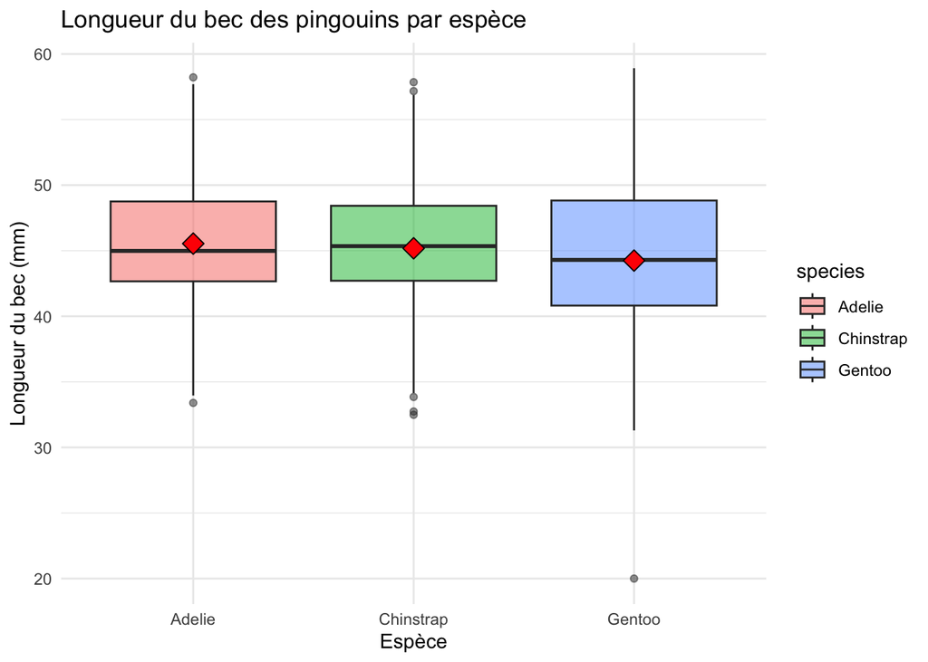

```r
ggplot(penguins_mission, aes(x = species, y = bill_length_mm, fill = species)) +
  geom_boxplot(alpha = 0.5) +
  stat_summary(fun = mean, geom = "point", shape = 23, size = 4, fill = "red") +
  labs(title = "Longueur du bec des pingouins par espèce",
       x = "Espèce",
       y = "Longueur du bec (mm)") +
  theme_minimal()
```

**📜 Instructions laissées par la chercheuse**

Pour connaître la tâche optionnelle de la chercheuse :

```
[1] "J'ai commencé à faire le ggplot, mais il resterait a ajouter une annotation indiquant la valeur moyenne de chaque espèce sur le graphique."
```

**Exercice**

Completer le code `ggplot2` du Dr Adélie afin de répondre à sa demande. Inclure cela dans votre journal de bord. Dites en quoi ce graphique avancé peut aider à comprendre mieux nos données.

**Pensez à générer votre rapport, committer vos modifications et pousser sur GitHub pour garder une trace de votre travail ! 🚀**

🎯 Félicitations ! Vous avez maintenant terminer la partie 1 de cette aventure, vous pouvez allez vous reposer un peu avant la prochaine partie de cette mission! 🐧🚀

**🧑‍💼 Jules – Quand faire un commit ?**

À quel moment devrais-tu faire un commit Git ?  
1. Une fois à la toute fin du projet  
2. À chaque fois que tu ajoutes un graphique  
3. Régulièrement après chaque étape importante  
4. Seulement après une erreur

**✅ Réponse de Jules**

Tu dois faire un commit **après chaque étape significative** (import, filtre, graphique, analyse).  
🧠 Cela assure la traçabilité, et te sauvera du stress si tu dois revenir en arrière.

# 🐧 Le retour du Dr Adélie Fortier! (2e partie de l’aventure)

🔎 Après plusieurs semaines en Antarctique à observer les manchots, notre chercheuse est de retour avec pleins de nouvelles questions en tête. Elle a remarqué que certaines espèces semblaient avoir des caractéristiques bien distinctes, mais elle aimerait une analyse plus approfondie qui va l’aider a obtenir une nouvelle subvention pour son projet de recherche.

📘 **Rappel des livrables de la deuxième partie** :  
Un **rapport structuré et complet** répondant à ses nouvelles demandes précises, incluant :

- Des visualisations ciblées.
- Des analyses précises basées sur vos découvertes antérieures.
- Une mise en forme professionnelle (titre, légendes, axes lisibles, cohérence graphique).
- Un suivi rigoureux via **GitHub**, incluant plusieurs commits bien commentés.
- Elle vous donnera une liste de tâches claires et précises à répondre.

> **Note**: vous devez batir vous même votre rapport quarto pour l’aider dans sa demande de subvention. Commencer par créer un nouveau rapport QMD.

Sa question principale : 👉 Comment les caractéristiques physiques des manchots varient-elles selon les espèces ?

Pour l’aider, vous réaliserez une analyse complète, en mobilisant toutes les compétences acquises dans ce module.

**📌 Question 1**

Existe-t-il des différences notables entre les espèces de manchots ?

➡️ Pour y répondre, vous devez explorer les différences entre les caractéristiques physiques des trois espèces.

✅ Tâches :

Calculez la moyenne et l’écart-type des variables suivantes par espèce :

- Longueur du bec (`bill_length_mm`)
- Profondeur du bec (`bill_depth_mm`)
- Longueur des nageoires (`flipper_length_mm`)
- Masse corporelle (`body_mass_g`)

Affichez les résultats sous forme de tableau clair.

💡 Indice : Utilisez `group_by()` et `summarise()` de `dplyr` pour obtenir ces statistiques.

**🔬 Question 2**

Peut-on identifier un indicateur de “*grandeur*” du manchot ?

➡️ La chercheuse aimerait une nouvelle variable qui pourrait représenter la taille globale d’un manchot.

✅ Tâches :

- Créez une nouvelle variable **`indice_grandeur`** , définie comme la somme de :
  - La longueur des nageoires (flipper_length_mm)
  - La longueur du bec (bill_length_mm)
- Ajoutez cette variable au jeu de données et affichez quelques valeurs pour vérifier son calcul.

💡 Indice : Utilisez `mutate()` pour ajouter la variable à votre data.frame.

**🔬 Question 3**

Comment ces caractéristiques sont-elles réparties entre les espèces ?

➡️ Pour mieux visualiser les différences entre les espèces, la chercheuse vous demande de créer des graphiques.

✅ Tâches :

- Un histogramme de la longueur du bec (`bill_length_mm`) par espèce.
- Un nuage de points montrant la relation entre **`indice_grandeur`** et la masse corporelle (`body_mass_g`), en colorant par espèce.

Attention, n’oubliez pas vos bonnes pratiques de visualisation.

**✍️ Conclusion**

- Que remarquez-vous ?
- Quelles sont les différences les plus marquantes entre les espèces ?

**Pensez à générer votre rapport, committer vos modifications et pousser sur GitHub pour garder une trace de votre travail ! 🚀**

🎯 **Mission réussie !** Vous avez aidé le Dr Adélie Fortier à analyser les données des manchots avec succès ! 🚀